# Practical Machine Learning - Final project

Sumedh

4/18/2020

## Background.

Using devices such as Jawbone Up, Nike FuelBand, and Fitbit it is now possible to collect a large amount of data about personal activity relatively inexpensively. These type of devices are part of the quantified self movement – a group of enthusiasts who take measurements about themselves regularly to improve their health, to find patterns in their behavior, or because they are tech geeks. One thing that people regularly do is quantify how much of a particular activity they do, but they rarely quantify how well they do it. In this project, your goal will be to use data from accelerometers on the belt, forearm, arm, and dumbell of 6 participants. They were asked to perform barbell lifts correctly and incorrectly in 5 different ways. More information is available from the website here: http://web.archive.org/web/20161224072740/http:/groupware.les.inf.puc-rio.br/har (see the section on the Weight Lifting Exercise Dataset).

### Libraries used :

```r
library(ggplot2)
library(lattice)
library(caret)
library(rattle)
```

Note: ‘ggplot2’ and ‘lattice’ are dependencies required for the ‘caret’ package

### Now, we load the data into variables :-> TrainData & TestData

```r
TrainData <- read.csv(url("https://d396qusza40orc.cloudfront.net/predmachlearn/pml-training.csv"),header=TRUE)
dim(TrainData)
```

```
## [1] 19622   160
```

```r
TestData <- read.csv(url("https://d396qusza40orc.cloudfront.net/predmachlearn/pml-testing.csv"),header=TRUE)
dim(TestData)
```

```
## [1]  20 160
```

### Lets have a look at the data to get an understanding of it.

```r
str(TrainData)
```

```
## 'data.frame':    19622 obs. of  160 variables:
##  $ X                       : int  1 2 3 4 5 6 7 8 9 10 ...
##  $ user_name               : Factor w/ 6 levels "adelmo","carlitos",..: 2 2 2 2 2 2 2 2 2 2 ...
##  $ raw_timestamp_part_1    : int  1323084231 1323084231 1323084231 1323084232 1323084232 1323084232 1323084232 1323084232 1323084232 1323084232 ...
##  $ raw_timestamp_part_2    : int  788290 808298 820366 120339 196328 304277 368296 440390 484323 484434 ...
##  $ cvtd_timestamp          : Factor w/ 20 levels "02/12/2011 13:32",..: 9 9 9 9 9 9 9 9 9 9 ...
##  $ new_window              : Factor w/ 2 levels "no","yes": 1 1 1 1 1 1 1 1 1 1 ...
##  $ num_window              : int  11 11 11 12 12 12 12 12 12 12 ...
##  $ roll_belt               : num  1.41 1.41 1.42 1.48 1.48 1.45 1.42 1.42 1.43 1.45 ...
##  $ pitch_belt              : num  8.07 8.07 8.07 8.05 8.07 8.06 8.09 8.13 8.16 8.17 ...
##  $ yaw_belt                : num  -94.4 -94.4 -94.4 -94.4 -94.4 -94.4 -94.4 -94.4 -94.4 -94.4 ...
##  $ total_accel_belt        : int  3 3 3 3 3 3 3 3 3 3 ...
##  $ kurtosis_roll_belt      : Factor w/ 397 levels "","-0.016850",..: 1 1 1 1 1 1 1 1 1 1 ...
##  $ kurtosis_picth_belt     : Factor w/ 317 levels "","-0.021887",..: 1 1 1 1 1 1 1 1 1 1 ...
##  $ kurtosis_yaw_belt       : Factor w/ 2 levels "","#DIV/0!": 1 1 1 1 1 1 1 1 1 1 ...
```

[output cut: 86 more lines]

Notice that many of the columns have mostly NA values. We need to get rid of these columns as their contribution is insignificant to the model or could also cause some problems. We will remove all such columns in which 90% of the values are NA. (This shall be done for both the TrainData and the TestData). To avoid confusion, we assign the new clean data to 2 new variables, TrainDataClean & TestDataClean.

```r
#Training data set
indColToRemove <- which(colSums(is.na(TrainData)|TrainData=="")>0.9*dim(TrainData)[1])
TrainDataClean <- TrainData[,-indColToRemove]
TrainDataClean <- TrainDataClean[,-c(1:7)]
dim(TrainDataClean)
```

```
## [1] 19622    53
```

```r
#Testing data set
indColToRemove <- which(colSums(is.na(TestData) |TestData=="")>0.9*dim(TestData)[1])
TestDataClean <- TestData[,-indColToRemove]
TestDataClean <- TestDataClean[,-1]
dim(TestDataClean)
```

```
## [1] 20 59
```

Let’s have a look at the clean data now.

```r
str(TrainDataClean)
```

```
## 'data.frame':    19622 obs. of  53 variables:
##  $ roll_belt           : num  1.41 1.41 1.42 1.48 1.48 1.45 1.42 1.42 1.43 1.45 ...
##  $ pitch_belt          : num  8.07 8.07 8.07 8.05 8.07 8.06 8.09 8.13 8.16 8.17 ...
##  $ yaw_belt            : num  -94.4 -94.4 -94.4 -94.4 -94.4 -94.4 -94.4 -94.4 -94.4 -94.4 ...
##  $ total_accel_belt    : int  3 3 3 3 3 3 3 3 3 3 ...
##  $ gyros_belt_x        : num  0 0.02 0 0.02 0.02 0.02 0.02 0.02 0.02 0.03 ...
##  $ gyros_belt_y        : num  0 0 0 0 0.02 0 0 0 0 0 ...
##  $ gyros_belt_z        : num  -0.02 -0.02 -0.02 -0.03 -0.02 -0.02 -0.02 -0.02 -0.02 0 ...
##  $ accel_belt_x        : int  -21 -22 -20 -22 -21 -21 -22 -22 -20 -21 ...
##  $ accel_belt_y        : int  4 4 5 3 2 4 3 4 2 4 ...
##  $ accel_belt_z        : int  22 22 23 21 24 21 21 21 24 22 ...
##  $ magnet_belt_x       : int  -3 -7 -2 -6 -6 0 -4 -2 1 -3 ...
##  $ magnet_belt_y       : int  599 608 600 604 600 603 599 603 602 609 ...
##  $ magnet_belt_z       : int  -313 -311 -305 -310 -302 -312 -311 -313 -312 -308 ...
##  $ roll_arm            : num  -128 -128 -128 -128 -128 -128 -128 -128 -128 -128 ...
```

[output cut: 39 more lines]

Good, now the data is much cleaner and the number of columns have reduced to 53 for the Training set.

### Create a partition of the training data set.

```r
set.seed(12345)
inTrain1 <- createDataPartition(TrainDataClean$classe, p=0.75, list=FALSE)
Train1 <- TrainDataClean[inTrain1,]
Test1 <- TrainDataClean[-inTrain1,]
dim(Train1)
```

```
## [1] 14718    53
```

```r
dim(Test1)
```

```
## [1] 4904   53
```

### We are now ready to Train the data onto models.

#### we will be using the following 3 models.

- classification tree
- random forest
- gradient boosting method

*Note*: In order to limit the effects of overfitting, and improve the efficicency of the models, we will use the *cross-validation technique. We will use 5 folds (usually, 5 or 10 can be used, but 10 folds gives higher run times with no significant increase of the accuracy).

We will train the data on the 3 models and form the *Confusion Matrix* to check for the accuracy of our model’s predictions.

## 1) Classification Tree.

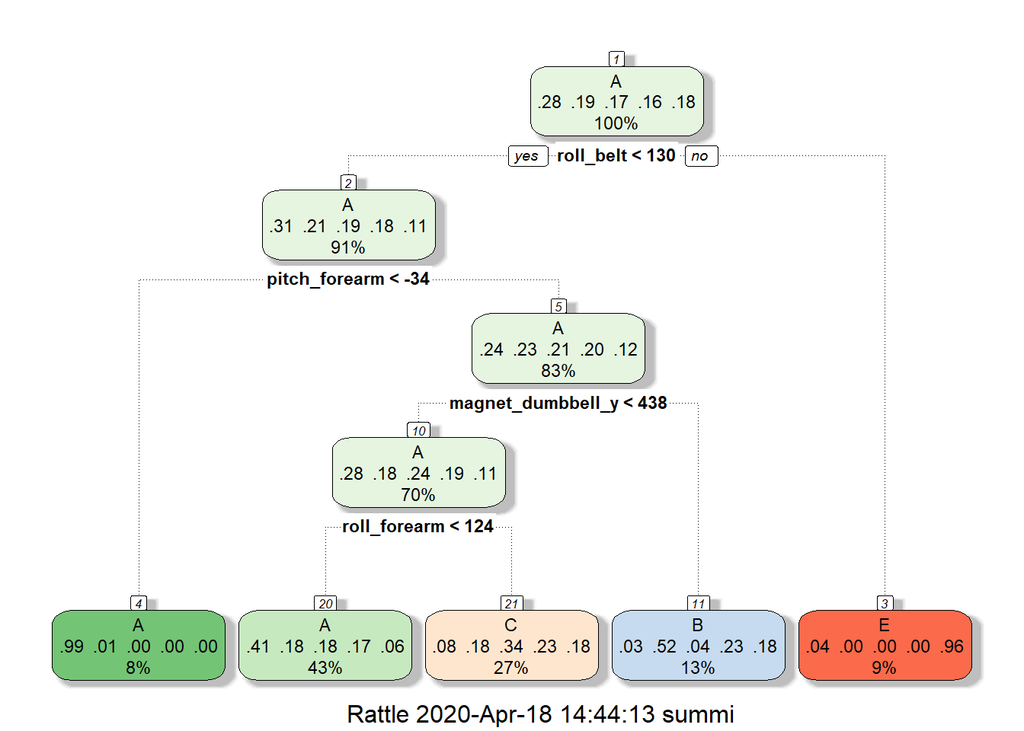

```r
trControl <- trainControl(method="cv", number=5)
model_CT <- train(classe~., data=Train1, method="rpart", trControl=trControl)
fancyRpartPlot(model_CT$finalModel)
```

```r
trainpred <- predict(model_CT,newdata=Test1)

confMatCT <- confusionMatrix(Test1$classe,trainpred)

# display confusion matrix and model accuracy
confMatCT$table
```

```
##           Reference
## Prediction    A    B    C    D    E
##          A 1252   30   90    0   23
##          B  396  317  236    0    0
##          C  434   24  397    0    0
##          D  343  151  310    0    0
##          E  114  132  229    0  426
```

```r
confMatCT$overall[1]
```

```
##  Accuracy
## 0.4877651
```

This model has an accuracy of 48.77% which is very low and will not give accurate predictions.

## 2) Random Forest.

```r
model_RF <- train(classe~.,data=Train1,method="rf",trControl=trControl,verbose=FALSE)
print(model_RF)
```

```
## Random Forest
##
## 14718 samples
##    52 predictor
##     5 classes: 'A', 'B', 'C', 'D', 'E'
##
## No pre-processing
## Resampling: Cross-Validated (5 fold)
## Summary of sample sizes: 11774, 11774, 11774, 11775, 11775
## Resampling results across tuning parameters:
##
##   mtry  Accuracy   Kappa
##    2    0.9919826  0.9898578
##   27    0.9913030  0.9889986
##   52    0.9851202  0.9811766
##
## Accuracy was used to select the optimal model using the largest value.
## The final value used for the model was mtry = 2.
```

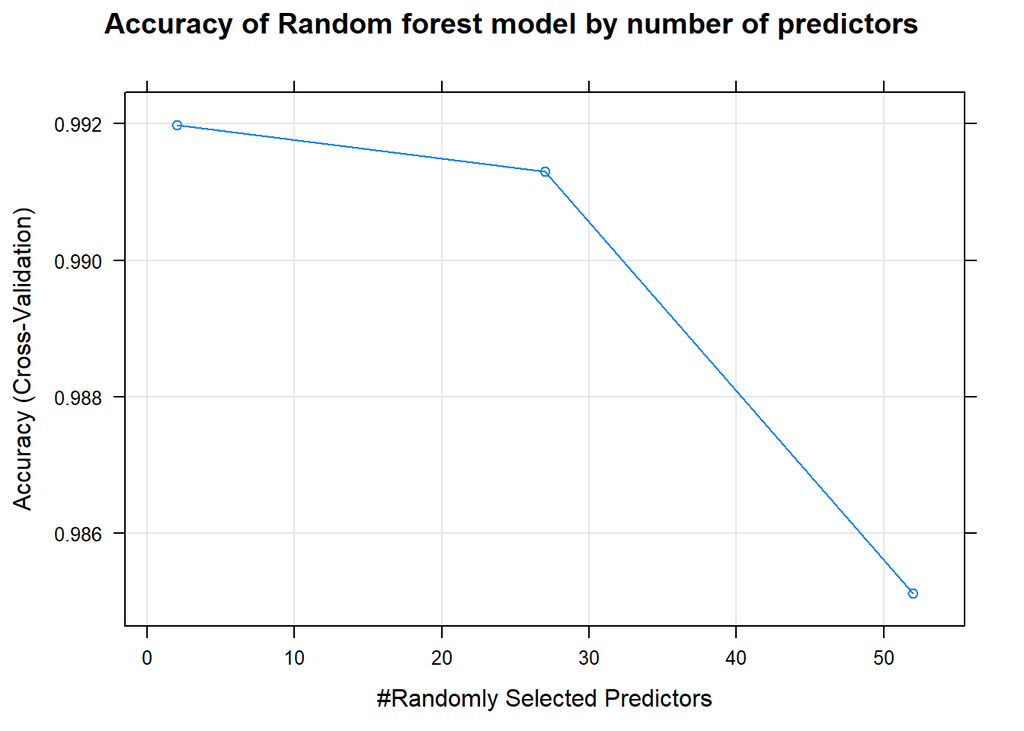

```r
plot(model_RF,main="Accuracy of Random forest model by number of predictors")
```

```r
trainpred <- predict(model_RF,newdata=Test1)

confMatRF <- confusionMatrix(Test1$classe,trainpred)

# display confusion matrix and model accuracy
confMatRF$table
```

```
##           Reference
## Prediction    A    B    C    D    E
##          A 1395    0    0    0    0
##          B    1  947    1    0    0
##          C    0    6  848    1    0
##          D    0    0   15  784    5
##          E    0    0    0    1  900
```

```r
confMatRF$overall[1]
```

```
##  Accuracy
## 0.9938825
```

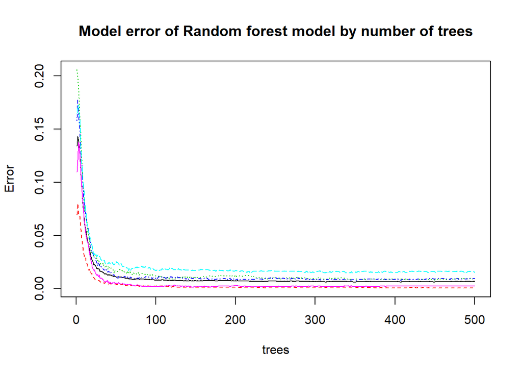

```r
plot(model_RF$finalModel,main="Model error of Random forest model by number of trees")
```

```r
# Compute the variable importance
MostImpVars <- varImp(model_RF)
MostImpVars
```

```
## rf variable importance
##
##   only 20 most important variables shown (out of 52)
##
##                      Overall
## roll_belt             100.00
## yaw_belt               84.34
## magnet_dumbbell_z      70.43
## pitch_belt             68.57
## magnet_dumbbell_y      66.35
## pitch_forearm          64.98
## magnet_dumbbell_x      58.47
## roll_forearm           54.69
## magnet_belt_z          48.50
## accel_dumbbell_y       47.87
## accel_belt_z           47.45
## magnet_belt_y          46.91
## roll_dumbbell          44.95
## accel_dumbbell_z       38.86
## roll_arm               36.37
## accel_forearm_x        34.36
## gyros_belt_z           32.40
## accel_arm_x            30.69
## accel_dumbbell_x       30.69
## total_accel_dumbbell   29.33
```

With random forest, we reach an accuracy of 99.3% using cross-validation with 5 steps. This is very good. But let’s see what we can expect with Gradient boosting.

At last, using more than about 30 trees does not reduce the error significantly.

## 3) Gradient Boosting

```r
model_GBM <- train(classe~.,data=Train1,method="gbm",trControl=trControl,verbose=FALSE)
print(model_GBM)
```

```
## Stochastic Gradient Boosting
##
## 14718 samples
##    52 predictor
##     5 classes: 'A', 'B', 'C', 'D', 'E'
##
## No pre-processing
## Resampling: Cross-Validated (5 fold)
## Summary of sample sizes: 11775, 11775, 11773, 11775, 11774
## Resampling results across tuning parameters:
##
##   interaction.depth  n.trees  Accuracy   Kappa
##   1                   50      0.7462973  0.6781972
##   1                  100      0.8225303  0.7753540
##   1                  150      0.8533772  0.8144003
##   2                   50      0.8530367  0.8138575
##   2                  100      0.9056940  0.8806589
##   2                  150      0.9315808  0.9134275
##   3                   50      0.8986280  0.8716423
##   3                  100      0.9451697  0.9306158
##   3                  150      0.9612723  0.9510047
##
## Tuning parameter 'shrinkage' was held constant at a value of 0.1
##
## Tuning parameter 'n.minobsinnode' was held constant at a value of 10
## Accuracy was used to select the optimal model using the largest value.
## The final values used for the model were n.trees = 150, interaction.depth =
##  3, shrinkage = 0.1 and n.minobsinnode = 10.
```

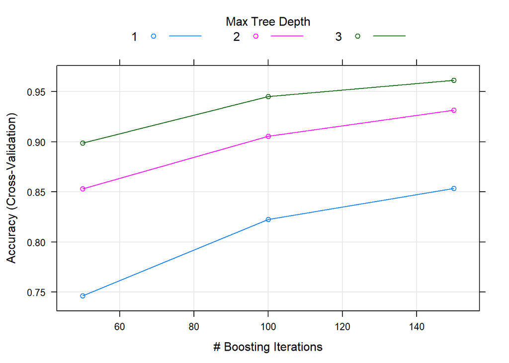

```r
plot(model_GBM)
```

```r
trainpred <- predict(model_GBM,newdata=Test1)
confMatGBM <- confusionMatrix(Test1$classe,trainpred)
confMatGBM$table
```

```
##           Reference
## Prediction    A    B    C    D    E
##          A 1371   17    1    6    0
##          B   23  896   28    2    0
##          C    0   29  810   16    0
##          D    0    2   38  760    4
##          E    0    8   10   10  873
```

```r
confMatGBM$overall[1]
```

```
##  Accuracy
## 0.9604405
```

## Conclusion:

*Randon Forest* is the best prediction algorithm for this set of data. Thus, we use the model generated by this algorithm for our predictions:

```r
FinalTestPred <- predict(model_RF,newdata=TestDataClean)
FinalTestPred
```

```
##  [1] B A B A A E D B A A B C B A E E A B B B
## Levels: A B C D E
```

Here’s a link to my [github repository](https://github.com/Sumedh100/MachineLearningProject) for the code and Rmarkdown file.